# PracticalMachineLearning_ROBMILL

### Final Peer Reviewed Assignment

## Practical Machine Learning

## Week 4

```r
# Load Librarys
# Load Data
library(kernlab)
library(caret)
```

```r
library(ggplot2)
library(Hmisc)
library(gridExtra)
library(graphics)

training<-read.csv(file = "pml-training.csv",stringsAsFactors = FALSE) # Read training data

training<-read.csv(file = "pml-trainingMod.csv",
                   stringsAsFactors = FALSE)

testing<-read.csv(file = "pml-testing.csv",stringsAsFactors = FALSE) # Read testing data
```

### Initial EDA on Raw Data Set

Data comes from: 1. http://groupware.les.inf.puc-rio.br/har 2. http://groupware.les.inf.puc-rio.br/har#weight_lifting_exercises

The data set describes quality of execution for the wearer while doing dumbell lift exercises.

Different Classes of execution quality. High level Class A represents an example of successful execution of the exercise while Classes B-E represent examples of common mistakes made.

- Class A: exactly according to specification.
- Class B: throwing the elbows to the front.
- Class C: lifting the dumbell only halfway.
- Class D: lowering dumbell only halfway.
- Class E: throwing the hips to the front.

### The goal of the exercise is to identify predictors that accurately determine execution quality or manner of exercise.

Similar to the iris data set exercise predicting species based on a set of features. q

```r
dim(training) # display number or rows/columns
```

```
## [1] 19622    60
```

```r
# str(training) # display features
# summary(training) # display summary stats
#names(training)
head(training)
```

```
##   X user_name raw_timestamp_part_1 raw_timestamp_part_2 cvtd_timestamp
## 1 1  carlitos           1323084231               788290  5/12/11 11:23
## 2 2  carlitos           1323084231               808298  5/12/11 11:23
## 3 3  carlitos           1323084231               820366  5/12/11 11:23
## 4 4  carlitos           1323084232               120339  5/12/11 11:23
## 5 5  carlitos           1323084232               196328  5/12/11 11:23
## 6 6  carlitos           1323084232               304277  5/12/11 11:23
##   new_window num_window roll_belt pitch_belt yaw_belt total_accel_belt
## 1         no         11      1.41       8.07    -94.4                3
## 2         no         11      1.41       8.07    -94.4                3
## 3         no         11      1.42       8.07    -94.4                3
## 4         no         12      1.48       8.05    -94.4                3
## 5         no         12      1.48       8.07    -94.4                3
## 6         no         12      1.45       8.06    -94.4                3
##   gyros_belt_x gyros_belt_y gyros_belt_z accel_belt_x accel_belt_y
```

[output cut: 76 more lines]

```r
table(training$classe)
```

```
##
##    A    B    C    D    E
## 5580 3797 3422 3216 3607
```

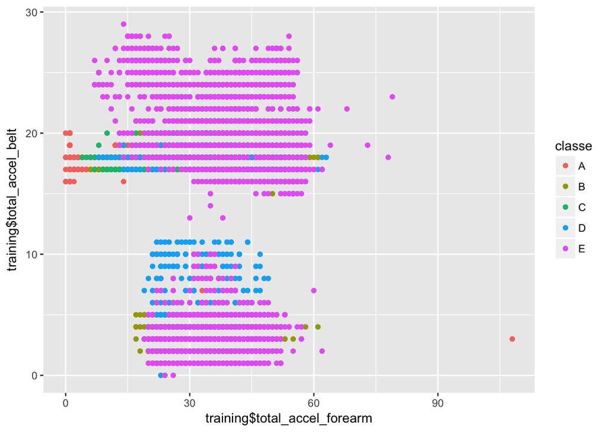

```r
qplot(training$total_accel_forearm,training$total_accel_belt,colour=classe,data=training)
```

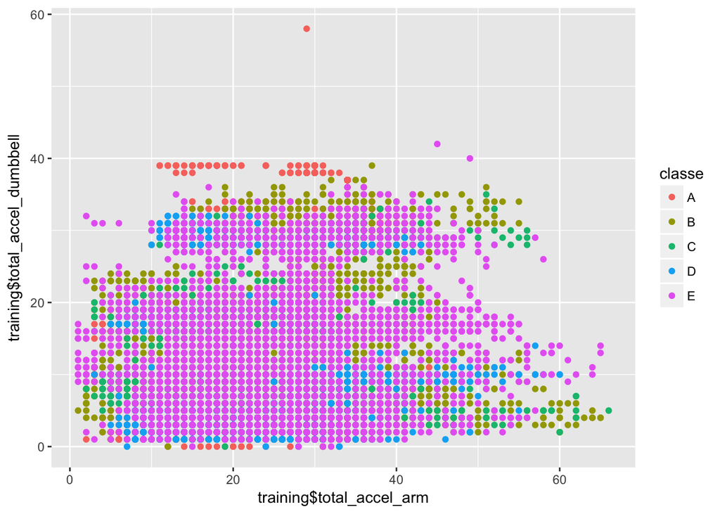

```r
qplot(training$total_accel_arm,training$total_accel_dumbbell,colour=classe,data=training)
```

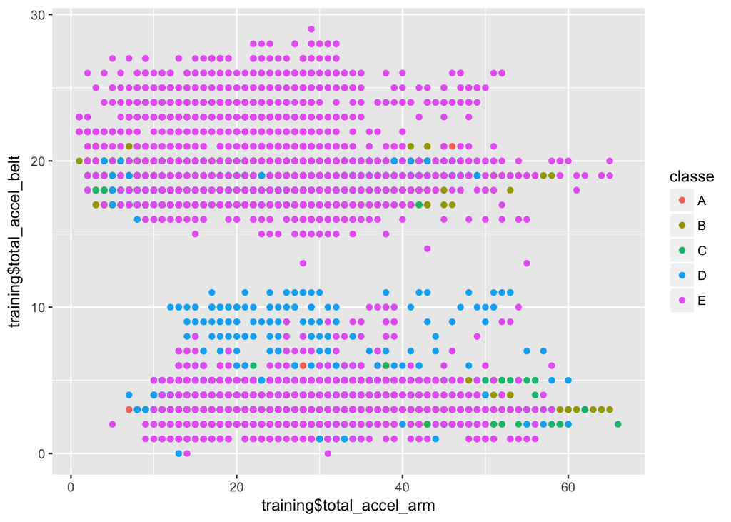

```r
qplot(training$total_accel_arm,training$total_accel_belt,colour=classe,data=training)
```

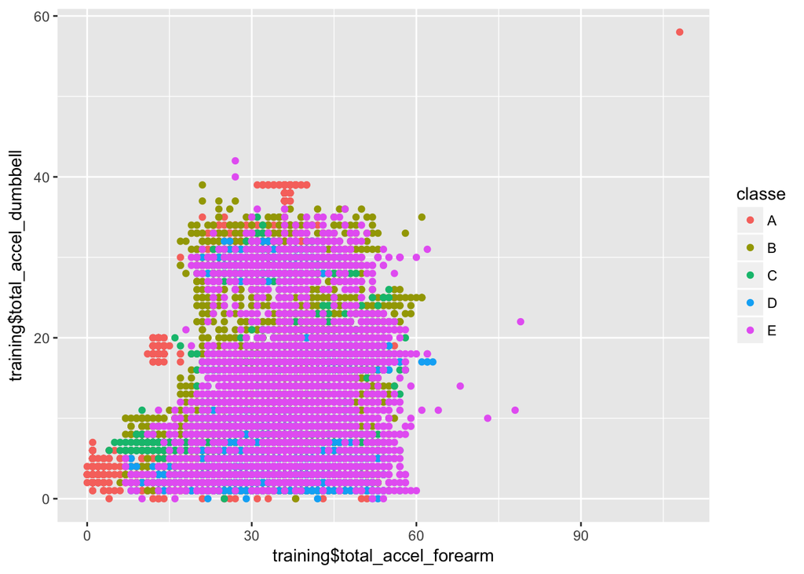

```r
qplot(training$total_accel_forearm,training$total_accel_dumbbell,colour=classe,data=training)
```

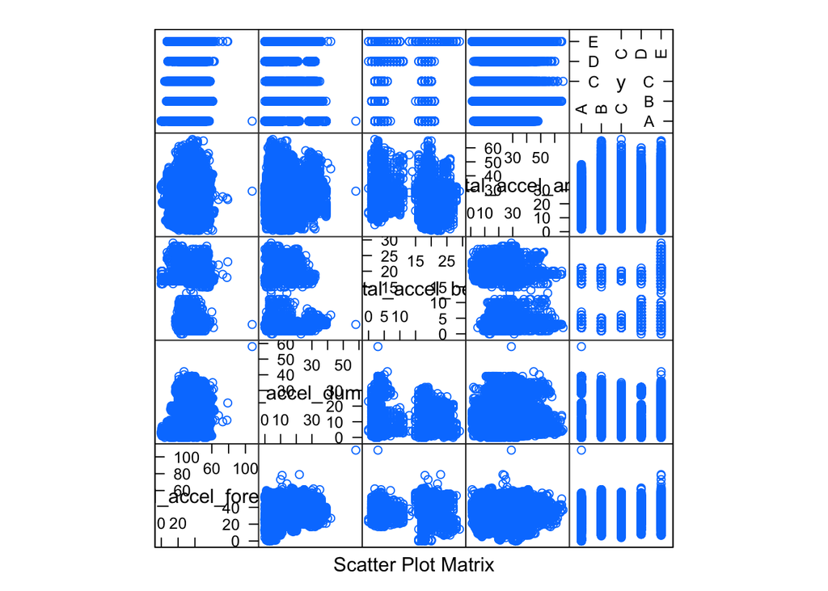

```r
featurePlot(x=training[,c("total_accel_forearm","total_accel_dumbbell","total_accel_belt","total_accel_arm")], y=training$classe, plot="pairs")
```

### Partition Training Data and Processing

```r
inTrain<-createDataPartition(training$classe,p=0.70,list=FALSE)

trainingSub<-training[inTrain,]
testingSub<-training[-inTrain,]
```

```r
modFit.rpart<-train(classe~total_accel_dumbbell+total_accel_arm+total_accel_belt,method="rpart",data=training)
print(modFit.rpart$finalModel)
```

```
## n= 19622
##
## node), split, n, loss, yval, (yprob)
##       * denotes terminal node
##
##  1) root 19622 14042 A (0.28 0.19 0.17 0.16 0.18)
##    2) total_accel_belt< 21.5 18778 13198 A (0.3 0.2 0.18 0.17 0.15)
##      4) total_accel_dumbbell>=29.5 2271   992 A (0.56 0.13 0.066 0.12 0.12) *
##      5) total_accel_dumbbell< 29.5 16507 12206 A (0.26 0.21 0.2 0.18 0.15)
##       10) total_accel_dumbbell< 5.5 5701  3534 A (0.38 0.12 0.17 0.24 0.096) *
##       11) total_accel_dumbbell>=5.5 10806  7968 B (0.2 0.26 0.22 0.15 0.18) *
##    3) total_accel_belt>=21.5 844     0 E (0 0 0 0 1) *
```

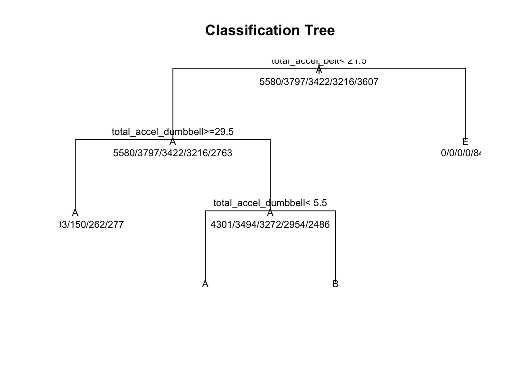

```r
plot(modFit.rpart$finalModel,uniform=TRUE,
     main="Classification Tree")
text(modFit.rpart$finalModel,use.n=TRUE,all=TRUE,cex=0.8)
```

```r
predictions.rpart<-predict(modFit.rpart,newdata=testing)
```

```r
#modFit.rf<-train(classe~total_accel_dumbbell+total#_accel_arm+total_accel_belt,data=training,method="#rf",prox=TRUE)
```

### Run a Boosting Algorithm against all features

- modFit.boost<-train(classe~.,method=“gbm”, data=training, verbose=FALSE)

```r
print(modFit.boost)
```

```
## Stochastic Gradient Boosting
##
## 19622 samples
##    59 predictor
##     5 classes: 'A', 'B', 'C', 'D', 'E'
##
## No pre-processing
## Resampling: Bootstrapped (25 reps)
## Summary of sample sizes: 19622, 19622, 19622, 19622, 19622, 19622, ...
## Resampling results across tuning parameters:
##
##   interaction.depth  n.trees  Accuracy   Kappa
##   1                   50      0.9997120  0.9996357
##   1                  100      0.9997120  0.9996358
##   1                  150      0.9997010  0.9996218
##   2                   50      0.9997066  0.9996289
##   2                  100      0.9997067  0.9996290
##   2                  150      0.9997177  0.9996429
##   3                   50      0.9997011  0.9996220
##   3                  100      0.9997067  0.9996290
##   3                  150      0.9997122  0.9996360
##
## Tuning parameter 'shrinkage' was held constant at a value of 0.1
##
## Tuning parameter 'n.minobsinnode' was held constant at a value of 10
## Accuracy was used to select the optimal model using  the largest value.
## The final values used for the model were n.trees = 150,
##  interaction.depth = 2, shrinkage = 0.1 and n.minobsinnode = 10.
```

## Citation

Velloso, E.; Bulling, A.; Gellersen, H.; Ugulino, W.; Fuks, H. Qualitative Activity Recognition of Weight Lifting Exercises. Proceedings of 4th International Conference in Cooperation with SIGCHI (Augmented Human ’13) . Stuttgart, Germany: ACM SIGCHI, 2013.

Read more: http://groupware.les.inf.puc-rio.br/har#weight_lifting_exercises#ixzz4aHsvXnQK

### Useful links

[Preprocess method](https://www.rdocumentation.org/packages/caret/versions/6.0-73/topics/preProcess)